# Graficador de funciones

Comenzamos por importar las librerías necesarias

```python
import tkinter as tk
from tkinter import ttk
import matplotlib.pyplot as plt
import numpy as np
from matplotlib import interactive
import pandas as pd
import sympy as sp
```

Creamos las opciones de la ventana y del menú

```python
# Instanciamos
ventana = tk.Tk()
# Titulo de la ventana
ventana.title('Graficador de funciones')
# Tamaño
ventana.config(width = 400, height = 200)
# Vemos como va hasta ahora nuestra ventana
ventana.mainloop()
```

Creamos ahora un espacio para que el usuario pueda ingresar la función que desea graficar

```python
# Texto
etiqueta_fun = ttk.Label(text='Ingrese la función')
etiqueta_fun.place(x = 20, y = 20)

# Caja para que el usuario ingrese la funcion
caja_fun = ttk.Entry()
caja_fun.place(x = 120, y = 20, width = 80)

# Vemos como vamos
ventana.mainloop()
```

Creamos un botón ahora para que se grafique la función ingresada

```python
# Graficar, este boton utilizara una funcion para que se pueda graficar
# Funcion, por el momento no hara nada
def graficar():
    pass

boton_graf = ttk.Button(text='Graficar', command = graficar)
boton_graf.place(x=20, y=40)
# Vemos como vamos
ventana.mainloop()
```

Recordemos cómo graficar funciones

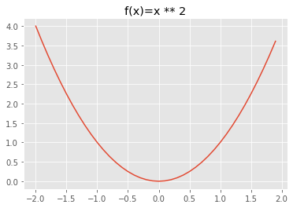

```python
plt.style.use('ggplot')

x = np.arange(-2,2, 0.1)
fun_str = 'x ** 2'
y = eval(fun_str)

plt.plot(x,y)
plt.title(f'f(x)={fun_str}')
plt.show()
```

Creamos la función graficar como sigue

```python
def graficar():
    # Estilo
    plt.style.use('ggplot')
    # Rango fijo
    x = np.arange(-3, 3, 0.1)
    # funcion (la obtenemos de la caja_fun)
    fun_str = caja_fun.get()
    y = eval(fun_str)
    # graficamos
    plt.plot(x, y)
    # Mostramos
    plt.title(f'f(x)={fun_str}')
    plt.show()
```

Probamos ahora todo el código junto

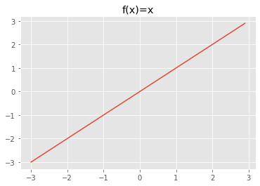

```python
# Instanciamos
ventana = tk.Tk()

# Titulo de la ventana
ventana.title('Graficador de funciones')

# Tamaño
ventana.config(width = 400, height = 200)

# Texto
etiqueta_fun = ttk.Label(text='Ingrese la función')
etiqueta_fun.place(x = 20, y = 20)

# Caja para que el usuario ingrese la funcion
caja_fun = ttk.Entry()
caja_fun.place(x = 120, y = 20, width = 80)

# Funcion para graficar asociado al boton de abajo
def graficar():
    # Estilo
    plt.style.use('ggplot')
    # Rango fijo
    x = np.arange(-3, 3, 0.1)
    # funcion (la obtenemos de la caja_fun)
    fun_str = caja_fun.get()
    y = eval(fun_str)
    # graficamos
    plt.plot(x, y)
    # Mostramos
    plt.title(f'f(x)={fun_str}')
    plt.show()

# Boton
boton_graf = ttk.Button(text='Graficar', command = graficar)
boton_graf.place(x=20, y=40)

# Vemos como vamos
ventana.mainloop()
```

Crearemos ahora más opciones mediante un menú: graficar, límite y derivadas. En la opción de graficar colocaremos una función para abrir una nueva ventana con el código anterior

```python
ventana = tk.Tk()
ventana.title('Cálculo Diferencial')
ventana.geometry('400x200')


# Creamos una barra de menus en la ventana
barra_menus = tk.Menu(ventana)
ventana.config(menu = barra_menus)

# Creamos un menu y lo anclamos
menu = tk.Menu(barra_menus, tearoff=False)

# funciones para abrir nuevas ventanas
def c_graficar():
    # Nueva ventana
    vc_graficar = tk.Toplevel()
    # ventana para graficar
    # ------------------------------------------------------

    # Texto
    etiqueta_fun = ttk.Label(vc_graficar, text='Ingrese la función')
    etiqueta_fun.place(x = 20, y = 20)

    # Caja para que el usuario ingrese la funcion
    caja_fun = ttk.Entry(vc_graficar)
    caja_fun.place(x = 120, y = 20, width = 80)

    # Funcion para graficar asociado al boton de abajo
    def graficar():
        # Estilo
        plt.style.use('ggplot')
        # Rango fijo
        x = np.arange(-3, 3, 0.1)
        # funcion (la obtenemos de la caja_fun)
        fun_str = caja_fun.get()
        y = eval(fun_str)
        # graficamos
        plt.plot(x, y)
        # Mostramos
        plt.title(f'f(x)={fun_str}')
        plt.show()

    # Boton
    boton_graf = ttk.Button(vc_graficar,text='Graficar', command = graficar)
    boton_graf.place(x=20, y=40)
    boton_graf_salir = ttk.Button(vc_graficar, text='Regresar', command = vc_graficar.destroy)
    boton_graf_salir.place(x=20, y=60)
    # ------------------------------------------------------

def c_limites():
    vc_limites = tk.Toplevel()
def c_derivadas():
    vc_derivadas = tk.Toplevel()

# Opciones del menu
menu.add_command(label = 'Graficador', command = c_graficar)
menu.add_command(label = 'Limites', command = c_limites)
menu.add_command(label = 'Derivadas', command = c_derivadas)

# linea separadora
menu.add_separator()
menu.add_command(label = 'Salir', command=ventana.destroy)
barra_menus.add_cascade(label='Menú', menu = menu)

# Texto
etiqueta1 = ttk.Label(ventana, text="¡Bienvenido!", font=('Helvetica', 16))
etiqueta1.place(x=50, y=20)
etiqueta2 = ttk.Label(ventana,
                      text="Este es un programa para graficar\ny calcular límites y derivadas.\nExplora las opciones del menú",
                      font=('Helvetica', 12))
etiqueta2.place(x=50, y=60)

ventana.mainloop()
```

### Configuración de la función c_graficar()

Configuraremos ahora la ventana de graficar para que pueda graficar más funciones y no sólo del tipo $x^{a}$.

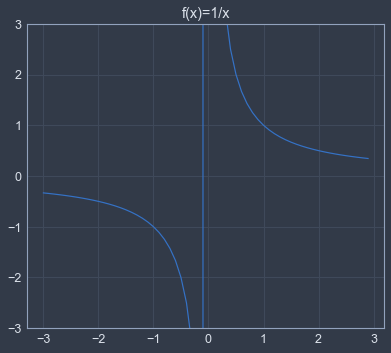

```python
# Estilo de gráficas en sintonia con el fondo
from jupyterthemes import jtplot
jtplot.style()


# Instanciamos
ventana = tk.Tk()

# Titulo de la ventana
ventana.title('Graficador de funciones')

# Tamaño
ventana.config(width = 500, height = 200)

# Texto
etiqueta_fun = ttk.Label(text='Ingrese la función')
etiqueta_fun.place(x = 20, y = 20)

# Caja para que el usuario ingrese la funcion
caja_fun = ttk.Entry()
caja_fun.place(x = 120, y = 20, width = 100)

# Funcion para graficar x^a
def graficar():
    # Rango fijo
    x = np.arange(-3, 3, 0.1, dtype=float)
    # funcion (la obtenemos de la caja_fun)
    fun_str = caja_fun.get()
    y = eval(fun_str)
    # graficamos
    plt.plot(x, y)
    # Mostramos
    plt.title(f'f(x)={fun_str}')
    plt.show()

# grafica de funciones racionales
def graficar_rac():
    # Rango fijo
    x = np.arange(-3, 3, 0.1, dtype=float)
    # funcion (la obtenemos de la caja_fun)
    fun_str = caja_fun.get()
    y = eval(fun_str)
    # graficamos
    plt.ylim(-3,3)
    plt.plot(x, y)
    # Mostramos
    plt.title(f'f(x)={fun_str}')
    plt.show()

# Funcion para graficar funciones trigonometricas
def graficar_trigo():
    # Rango fijo
    x = np.arange(-2 * np.pi, 2 * np.pi, 0.1, dtype=float)
    # funcion (la obtenemos de la caja_fun)
    fun_str1 = caja_fun.get()
    if fun_str1[:3] == 'tan':
        plt.ylim(-3,3)
    fun_str2 = 'np.' + fun_str1
    y = eval(fun_str2)
    # graficamos
    plt.plot(x, y)
    # Mostramos
    plt.title(f'f(x)={fun_str1}')
    plt.show()

# Funcion para graficar funciones logaritmicas y exponenciales
def graficar_exp():
    # Rango fijo
    x = np.arange(-3, 3, 0.1, dtype=float)
    # funcion (la obtenemos de la caja_fun)
    fun_str1 = caja_fun.get()
    fun_str2 = 'np.' + fun_str1
    y = eval(fun_str2)
    # graficamos
    plt.plot(x, y)
    # Mostramos
    plt.title(f'f(x)={fun_str1}')
    plt.show()

# Botones
boton_graf = ttk.Button(text='Graficar', command = graficar)
boton_graf.place(x=20, y=60)
boton_graf_trigono = ttk.Button(text='Graficar Trigonometric', command = graficar_trigo)
boton_graf_trigono.place(x=100, y=60)
boton_graf_exp = ttk.Button(text='Graficar Exp/ log', command = graficar_trigo)
boton_graf_exp.place(x=230, y=60)
boton_graf = ttk.Button(text='Graficar fun racional', command = graficar_rac)
boton_graf.place(x=330, y=60)
boton_graf_salir = ttk.Button(text='Regresar', command = ventana.destroy)
boton_graf_salir.place(x=20, y=100)

# Vemos como vamos
ventana.mainloop()
```

De tal manera, adaptaremos el código anterior para el menu principal en la fucnión c_graficar.

### Configuración de la función c_limites

```python
# Instanciamos
ventana = tk.Tk()

# Titulo de la ventana
ventana.title('Límites')

# Tamaño
ventana.config(width = 400, height = 200)

# Texto
etiqueta_fun = ttk.Label(text='Ingrese la función:')
etiqueta_fun.place(x = 20, y = 20)
etiqueta_fun = ttk.Label(text='Hacía qué valor\ntiende x:')
etiqueta_fun.place(x = 20, y = 40)

# Caja para que el usuario ingrese la funcion
caja_fun = ttk.Entry()
caja_fun.place(x = 120, y = 20, width = 100)
caja_x = ttk.Entry()
caja_x.place(x = 120, y = 50, width = 80)

# Funcion para graficar asociado al boton de abajo
def calcular_lim():
    limite = 0
    # Etiqueta
    etiqueta_resul_lim = ttk.Label(text = f'El límite de f(x)={caja_fun.get()} cuando x tiende a {caja_x.get()} es {limite}')
    etiqueta_resul_lim.place(x=20, y=120)

# Boton
boton_graf = ttk.Button(text='Calcular', command = calcular_lim)
boton_graf.place(x=20, y=80)


# Vemos como vamos
ventana.mainloop()
```

Ahora sólo falta configurar la función `calcular_lim()`. Recordemos cómo calcular límites

```python
import sympy as sp

# Definimos un simbolo
x = sp.symbols('x')

# funcion
y = 'x ** 2'

# calculo
sp.limit(y,x,0)
```

$\displaystyle 0$

Continuamos entonces

```python
# Instanciamos
ventana = tk.Tk()

# Titulo de la ventana
ventana.title('Límites')

# Tamaño
ventana.config(width = 400, height = 200)

# Texto
etiqueta_fun = ttk.Label(text='Ingrese la función:')
etiqueta_fun.place(x = 20, y = 20)
etiqueta_fun_x = ttk.Label(text='Hacía qué valor\ntiende x:')
etiqueta_fun_x.place(x = 20, y = 40)


# Caja para que el usuario ingrese la funcion
caja_fun = ttk.Entry()
caja_fun.place(x = 120, y = 20, width = 100)
caja_x = ttk.Entry()
caja_x.place(x = 120, y = 50, width = 80)

# Limpiar celdas de las cajas
def clear_text():
    caja_fun.delete(0, tk.END)
    caja_x.delete(0, tk.END)

# Funcion calcularel limite
def calcular_lim():
    x = sp.symbols('x')
    # funcion
    y = caja_fun.get()
    # Valor del limite
    limite = sp.limit(y,x, eval(caja_x.get()))
    # Etiqueta
    etiqueta_resul_lim = ttk.Label(text = f'El límite de f(x)={caja_fun.get()} cuando x tiende a {caja_x.get()} es {limite}')
    etiqueta_resul_lim.place(x=20, y=120)

# Boton
boton_calc = ttk.Button(text='Calcular', command = calcular_lim)
boton_calc.place(x=20, y=80)
boton_calc_nuevo = ttk.Button(text='Nuevo', command = clear_text)
boton_calc_nuevo.place(x=110, y=80)

boton_calc_salir = ttk.Button(text='Regresar', command = ventana.destroy)
boton_calc_salir.place(x=20, y=150)

# Vemos como vamos
ventana.mainloop()
```

### Función c_derivadas()

Procederemos de forma totalmente análoga al caso anterior

```python
# Instanciamos
ventana = tk.Tk()

# Titulo de la ventana
ventana.title('Derivadas')

# Tamaño
ventana.config(width = 400, height = 200)

# Texto
etiqueta_fun = ttk.Label(text='Ingrese la función:')
etiqueta_fun.place(x = 20, y = 20)
etiqueta_fun_ord = ttk.Label(text='Orden de \nderivación:')
etiqueta_fun_ord.place(x = 20, y = 40)


# Caja para que el usuario ingrese la funcion
caja_fun = ttk.Entry()
caja_fun.place(x = 120, y = 20, width = 100)
caja_ord = ttk.Entry()
caja_ord.place(x = 120, y = 50, width = 80)



# Limpiar celdas de las cajas
def clear_text():
    caja_fun.delete(0, tk.END)
    caja_ord.delete(0, tk.END)

# Funcion para calcular la derivada
def calcular_der():
    x = sp.symbols('x')
    # funcion
    x = sp.symbols('x')
    y = caja_fun.get()
    # derivada
    derivada = sp.diff(y,x,eval(caja_ord.get()))
    # Etiqueta
    etiqueta_resul_der = ttk.Label(text = f'La derivada de f(x)={caja_fun.get()} de orden {caja_ord.get()} es {derivada}')
    etiqueta_resul_der.place(x=20, y=120)

# Boton
boton_calc = ttk.Button(text='Calcular', command = calcular_der)
boton_calc.place(x=20, y=80)
boton_calc_imp = ttk.Button(text='Calc implícita', command = calcular_der)
boton_calc_imp.place(x=110, y=80)
boton_calc_nuevo = ttk.Button(text='Nuevo', command = clear_text)
boton_calc_nuevo.place(x=200, y=80)

boton_calc_salir = ttk.Button(text='Regresar', command = ventana.destroy)
boton_calc_salir.place(x=20, y=150)

# Vemos como vamos
ventana.mainloop()
```

Ahora bien, implementaremos una nueva funcionalidad en la opciones de límites. Esta opción nos mostrará gráficamente la aproximación que se realiza al resolver un límite dado

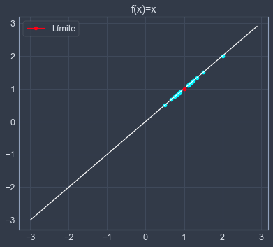

```python
from jupyterthemes import jtplot
jtplot.style()
# Instanciamos
ventana = tk.Tk()

# Titulo de la ventana
ventana.title('Límites')

# Tamaño
ventana.config(width = 400, height = 200)

# Texto
etiqueta_fun = ttk.Label(text='Ingrese la función:')
etiqueta_fun.place(x = 20, y = 20)
etiqueta_fun_x = ttk.Label(text='Hacía qué valor\ntiende x:')
etiqueta_fun_x.place(x = 20, y = 40)


# Caja para que el usuario ingrese la funcion
caja_fun = ttk.Entry()
caja_fun.place(x = 120, y = 20, width = 100)
caja_x = ttk.Entry()
caja_x.place(x = 120, y = 50, width = 80)

# Limpiar celdas de las cajas
def clear_text():
    caja_fun.delete(0, tk.END)
    caja_x.delete(0, tk.END)
# --------------------------------------------------
# --------------------------------------------------
# Funcion para calcular el limite
def calcular_lim():
    x = sp.symbols('x')
    # funcion
    y = caja_fun.get()
    # Valor del limite
    limite = sp.limit(y,x, eval(caja_x.get()))
    # Etiqueta
    etiqueta_resul_lim = ttk.Label(text = f'El límite de f(x)={caja_fun.get()} cuando x tiende a {caja_x.get()} es {limite}')
    etiqueta_resul_lim.place(x=20, y=120)
# --------------------------------------------------
# Graficar funciones
def graficar_lim():
    x = sp.symbols('x')
    # funcion
    y = caja_fun.get()
    # x tiende a
    x_tiende_str = caja_x.get()
    x_tiende = eval(x_tiende_str)
    # Valor del limite
    limite = sp.limit(y,x,x_tiende)
    # Tabulacion
    lista_fx = []
    lista_x = [x_tiende + 1 / i for i in range(-10,11) if (i!=0) and (x_tiende + 1 / i != 0)]
    for i in lista_x:
        x = i
        val_lista_fx = eval(y)
        lista_fx.append(val_lista_fx)
    valores = {'x': lista_x, 'f(x)': lista_fx}
    df = pd.DataFrame(valores)
    x = sp.symbols('x')
    # Graficamos los puntos de aproximacion
    for i in range(len(df)):
        plt.plot(df.iloc[i,0], df.iloc[i,1], marker='o', color='#00F7FF')
    # Rango fijo
    x = np.arange(-3, 3, 0.1, dtype=float)
    y = eval(y)
    # graficamos
    plt.plot(x, y, color = '#FFFFFF')
    plt.plot(x_tiende, limite, marker='o', color='#FF0015', label='Límite')
    # Mostramos
    plt.title(f'f(x)={caja_fun.get()}')
    plt.legend()
    plt.show()

# grafica de funciones racionales
def graficar_rac():
    x = sp.symbols('x')
    # funcion
    y = caja_fun.get()
    # x tiende a
    x_tiende_str = caja_x.get()
    x_tiende = eval(x_tiende_str)
    # Valor del limite
    limite = sp.limit(y,x,x_tiende)
    # Tabulacion
    lista_fx = []
    lista_x = [x_tiende + 1 / i for i in range(-10,11) if (i!=0) and (x_tiende + 1 / i != 0)]
    for i in lista_x:
        x = i
        val_lista_fx = eval(y)
        lista_fx.append(val_lista_fx)
    valores = {'x': lista_x, 'f(x)': lista_fx}
    df = pd.DataFrame(valores)
    x = sp.symbols('x')
    # Graficamos los puntos de aproximacion
    for i in range(len(df)):
        plt.plot(df.iloc[i,0], df.iloc[i,1], marker='o', color='#00F7FF')
    # Rango fijo
    x = np.arange(-3, 3, 0.1, dtype=float)
    y = eval(y)
    # graficamos
    plt.plot(x, y, color = '#FFFFFF')
    plt.plot(x_tiende, limite, marker='o', color='#FF0015')
    plt.ylim(-3,3)
    # Mostramos
    plt.title(f'f(x)={caja_fun.get()}')
    plt.show()

# Funcion para graficar funciones trigonometricas
def graficar_t_e():
    x = sp.symbols('x')
    # funcion
    y = caja_fun.get()
    # x tiende a
    x_tiende_str = caja_x.get()
    x_tiende = eval(x_tiende_str)
    # Valor del limite
    limite = sp.limit(y,x,x_tiende)
    # Tabulacion
    lista_fx = []
    lista_x = [x_tiende + 1 / i for i in range(-10,11) if (i!=0) and (x_tiende + 1 / i != 0)]
    y = 'np.' + y
    for i in lista_x:
        x = i
        val_lista_fx = eval(y)
        lista_fx.append(val_lista_fx)
    valores = {'x': lista_x, 'f(x)': lista_fx}
    df = pd.DataFrame(valores)
    x = sp.symbols('x')
    # Graficamos los puntos de aproximacion
    for i in range(len(df)):
        plt.plot(df.iloc[i,0], df.iloc[i,1], marker='o', color='#00F7FF')
    # Rango fijo
    if (caja_fun.get()[:3] == 'tan') or (caja_fun.get()[:3] == 'log'):
        plt.ylim(-3,3)
    x = np.arange(-3, 3, 0.1, dtype=float)
    y = eval(y)
    # graficamos
    plt.plot(x, y, color = '#FFFFFF')
    plt.plot(x_tiende, limite, marker='o', color='#FF0015')
    # Mostramos
    plt.title(f'f(x)={caja_fun.get()}')
    plt.show()


# Boton
boton_calc = ttk.Button(text='Calcular', command = calcular_lim)
boton_calc.place(x=20, y=80)
boton_calc_nuevo = ttk.Button(text='Nuevo', command = clear_text)
boton_calc_nuevo.place(x=110, y=80)

boton_calc_salir = ttk.Button(text='Regresar', command = ventana.destroy)
boton_calc_salir.place(x=20, y=150)
boton_calc_graf_lim = ttk.Button(text='Graf_lim', command = graficar_lim)
boton_calc_graf_lim.place(x=100, y=150)
boton_calc_graf_rac = ttk.Button(text='Graf_rac', command = graficar_rac)
boton_calc_graf_rac.place(x=180, y=150)
boton_calc_graf_t_e = ttk.Button(text='Graf_trigo|exp', command = graficar_t_e)
boton_calc_graf_t_e.place(x=260, y=150)

# Vemos como vamos
ventana.mainloop()
```

Finalmente agregaremos nuevos elementos a la opción de derivadas

```python
# Instanciamos
vc_derivadas = tk.Tk()

# Titulo de la ventana
vc_derivadas.title('Derivadas')

# Tamaño
vc_derivadas.config(width = 500, height = 200)

# Texto
etiqueta_fun = ttk.Label(vc_derivadas, text='Ingrese la función:')
etiqueta_fun.place(x = 20, y = 20)
etiqueta_fun_ord = ttk.Label(vc_derivadas, text='Orden de \nderivación:')
etiqueta_fun_ord.place(x = 20, y = 40)


# Caja para que el usuario ingrese la funcion
caja_fun = ttk.Entry(vc_derivadas)
caja_fun.place(x = 120, y = 20, width = 100)
caja_ord = ttk.Entry(vc_derivadas)
caja_ord.place(x = 120, y = 50, width = 80)


# Limpiar celdas de las cajas
def clear_text():
    caja_fun.delete(0, tk.END)
    caja_ord.delete(0, tk.END)


# Funcion para calcular la derivada
def calcular_der():
    x = sp.symbols('x')
    # funcion
    x = sp.symbols('x')
    y = caja_fun.get()
    # derivada
    derivada = sp.diff(y,x,eval(caja_ord.get()))
    # Etiqueta
    etiqueta_resul_der = ttk.Label(vc_derivadas, text = f'La derivada de f(x)={caja_fun.get()} de orden {caja_ord.get()} es {derivada}')
    etiqueta_resul_der.place(x=20, y=120)

# Boton
boton_calc = ttk.Button(vc_derivadas, text='Calcular', command = calcular_der)
boton_calc.place(x=20, y=80)
boton_calc_imp = ttk.Button(vc_derivadas, text='Rectas tangentes', command = calcular_r_t)
boton_calc_imp.place(x=110, y=80)
boton_calc_nuevo = ttk.Button(vc_derivadas, text='Nuevo', command = clear_text)
boton_calc_nuevo.place(x=220, y=80)

boton_calc_salir = ttk.Button(vc_derivadas, text='Regresar', command = vc_derivadas.destroy)
boton_calc_salir.place(x=20, y=150)

# Vemos como vamos
vc_derivadas.mainloop()
```

```python
import sympy as sp
x = sp.symbols('x')

(2*x) * (x**2)
```

$\displaystyle 2 x^{3}$